# Example Analysis

```r
# Load libraries
library(tidyverse)
library(jsonlite)
library(dplyr)
library(ggplot2)
library(purrr)
library(sf)
library(knitr)
path = here::here()
```

## Objective

In this analysis, we want to understand the mortality trends in Baltimore, focusing on how various socioeconomic factors, such as vehicle availability, internet access, and fast food density, affect mortality rates across different age groups. The target audience for the analysis includes anyone that might be curious about public health and the mortality trends in Baltimore.

## Data

The data for this analysis was sourced from [Open Baltimore](https://data.baltimorecity.gov/search?q=*.) - a data set from the Baltimore City Health Department. Open Baltimore contains the urls for JSON files containing the data we need. Neighbourhood-specific mortality data for six different age groups (Infant, 1-14, 15-24, 25-44, 45-64, and 65-84) were collected for between 2011 and 2018.

We also downloaded socioeconomic data such as Percent of Households with No Vehicle Available, Percent of Households with No Internet at Home, and Fast Food Outlet Density per 1,000 Residents.

Next, we load the JSON files that were retrieved from the urls in Open Baltimore.

```r
# Load libraries
library(tidyverse)

# Load raw data
open_baltimore = read.csv("data/raw/Open Baltimore.csv")

# Filter data to only include rows that contain the word "mortality"
mortality_data = open_baltimore %>%
  filter(grepl("mortality", title, ignore.case = TRUE) |
         grepl("mortality", description, ignore.case = TRUE))

# Download json mortality data
mortality_urls = paste0(mortality_data$url,
              "/0/query?where=1%3D1&outFields=*&outSR=4326&f=json")

## Helper function to extract ages from the title of each mortality data file
extract_ages = function(title) {
  if (!grepl("\\d+-\\d+", title)) {
    return("infant")
  }

  else {
    return(stringr::str_extract(title, regex("\\d+-\\d+")))
  }
}

ages = mapply(extract_ages, mortality_data$title)
mortality_filenames = paste0("data/json/mortality_", ages, ".json")
mapply(curl::curl_download, urls, filenames)

# Download the data for (1) percentage of households with no vehicles available,
# (2) percentage of households with no internet at home, and (3) fast food
# outlet density per 1,000 residents.

socioeconomic_data = open_baltimore %>%
  filter(grepl("Percent of Households with No Vehicles Available", title, ignore.case = TRUE) |
           grepl("Percent of Households with No Internet at Home", title, ignore.case = TRUE) |
           grepl("Fast Food Outlet Density per 1,000 Residents", title, ignore.case = TRUE))

socioeconomic_urls = paste0(socioeconomic_data$url,
              "/0/query?where=1%3D1&outFields=*&outSR=4326&f=json")

socioeconomic_filenames = c("data/json/fastfood.json", "data/json/no_vehicles.json", "data/json/no_internet.json")
mapply(curl::curl_download, urls, filenames)
```

After loading the data, we extract important features, such as mortality rate and transform the data to long format for visualization. An example of how this is done is below.

```r
# Function to extract attributes from the JSON structure
extract_attributes <- function(json_data) {
  map_df(json_data$features, ~ .x$attributes)
}

# Read mortality data for each age group
mortality_infant <- read_json(paste0(path,"/data/json/mortality_infant.json")) %>% extract_attributes()
mortality_1_14 <- read_json(paste0(path, "/data/json/mortality_1-14.json")) %>% extract_attributes()
mortality_15_24 <- read_json(paste0(path, "/data/json/mortality_15-24.json")) %>% extract_attributes()
mortality_25_44 <- read_json(paste0(path, "/data/json/mortality_25-44.json")) %>% extract_attributes()
mortality_45_64 <- read_json(paste0(path, "/data/json/mortality_45-64.json")) %>% extract_attributes()
mortality_65_84 <- read_json(paste0(path, "/data/json/mortality_65-84.json")) %>% extract_attributes()

# Read predictor data (e.g., no internet, no vehicles, fast food)
no_internet <- read_json(paste0(path, "/data/json/no_internet.json")) %>% extract_attributes()
no_vehicles <- read_json(paste0(path, "/data/json/no_vehicles.json")) %>% extract_attributes()
fast_food <- read_json(paste0(path, "/data/json/fastfood.json")) %>% extract_attributes()

# Reshape data to long format for plotting
reshape_to_long = function(data, age_group, prefix, value) {
  data %>%
    select(CSA2010, starts_with(prefix)) %>%
    pivot_longer(cols = starts_with(prefix), names_to = "year", values_to = paste0(value, "_rate")) %>%
    mutate(year = as.integer(str_extract(year, "\\d+$")),
           age_group = age_group)
  # data$mean = rep(mean(data$morality_rate), nrow(data))
}

mortality_data <- bind_rows(
  reshape_to_long(mortality_infant, "Infant", "mort1", "mort"),
  reshape_to_long(mortality_1_14, "1-14", "mort14", "mort"),
  reshape_to_long(mortality_15_24, "15-24", "mort24", "mort"),
  reshape_to_long(mortality_25_44, "25-44", "mort44", "mort"),
  reshape_to_long(mortality_45_64, "45-64", "mort64", "mort"),
  reshape_to_long(mortality_65_84, "65-84", "mort84", "mort"))
mortality_data$year = mortality_data$year + 2000
mean_mortality = mortality_data %>% group_by(age_group, year) %>% summarise(mean_mort = mean(mort_rate, na.rm = TRUE))
```

After reading in theh JSON files and extracting our desired features, the data dictionary looks like this.

```r
head(mortality_data)
```

```
# A tibble: 6 × 4
  CSA2010                        year mort_rate age_group
  <chr>                         <dbl>     <dbl> <chr>
1 Allendale/Irvington/S. Hilton  2011     14.8  Infant
2 Allendale/Irvington/S. Hilton  2012     16.9  Infant
3 Allendale/Irvington/S. Hilton  2013     14.1  Infant
4 Allendale/Irvington/S. Hilton  2014     11.4  Infant
5 Allendale/Irvington/S. Hilton  2015     10.6  Infant
6 Allendale/Irvington/S. Hilton  2016      8.99 Infant
```

## Results

#### Mortality Over Time by Age Group

Figure 1 visualizes mortality rates across multiple age groups (Infant, 1-14, 15-24, 25-44, 45-64, and 65-84) from 2011 to 2018.

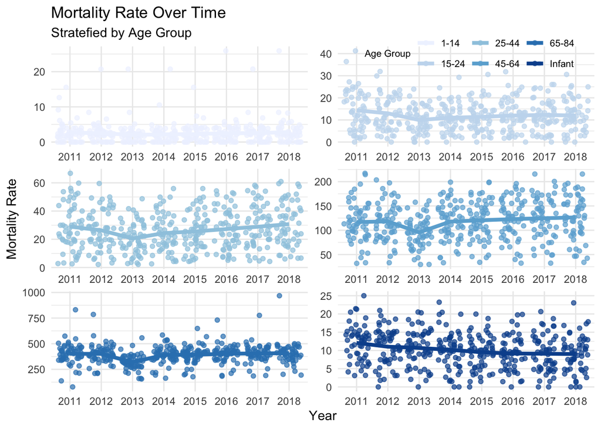

Figure 1: Mortality Over Time by Age Group

```r
# Plot mortality rates for each age group over time
ggplot(mortality_data, aes(x = as.factor(year), y = mort_rate, color = age_group)) +
  geom_jitter(alpha = 0.7) +
  geom_line(data = mean_mortality, aes(x = as.factor(year), y = mean_mort, group = age_group), size = 1.5) +
  facet_wrap(~age_group, scales = "free", ncol = 2) +
  theme_minimal() +
  labs(title = "Mortality Rate Over Time",
       subtitle = "Stratefied by Age Group",
       x = "Year",
       y = "Mortality Rate") +
  scale_color_brewer("Age Group", palette = "Blues") +
  theme(legend.position = c(.77,.98),
        legend.direction ="horizontal",
        legend.text = element_text(size = 8),
        legend.title = element_text(size = 8),
        strip.background = element_blank(),
        strip.text = element_blank())
```

#### Socioeconomic Covariates vs. Mortality Rates

The first panel shows the distributions of each socioeconomic covariate across Baltimore neighbourhoods. The remaining panels illustrate the relationships between each of the socioeconomic covariates and mortality rates, stratified by age group. For each covariate, we isolated the data to years where mortality data was also reported.

**Distribution of Sociodemographic Characteristics**

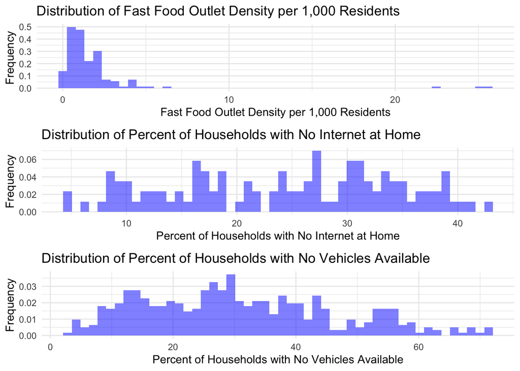

Figure 2: Visualizing the sociodemographic characteristics of the population.

```r
# Adding covariates to data frame
fastfd_data = reshape_to_long(fast_food[,1:5], "", "Fastfd", "fastfd") %>%
  subset(select = -c(age_group))
fastfd_data$year = fastfd_data$year + 2000
fastfd_mortality_data = inner_join(mortality_data, fastfd_data,
                                   by = c("CSA2010", "year"))
nohhint_data = reshape_to_long(no_internet[,1:4], "", "nohhint", "nohhint") %>%
  subset(select = -c(age_group))
nohhint_data$year = nohhint_data$year + 2000
nohhint_mortality_data = inner_join(mortality_data, nohhint_data,
                                   by = c("CSA2010", "year"))

novhcl_data = reshape_to_long(no_vehicles[,1:10], "", "novhcl", "novhcl") %>%
  subset(select = -c(age_group))
novhcl_data$year = novhcl_data$year + 2000
novhcl_mortality_data = inner_join(mortality_data, novhcl_data,
                                   by = c("CSA2010", "year"))

# Plot distribution of fast food density
D1 = ggplot(fastfd_data, aes(x = fastfd_rate)) +
  geom_histogram(aes(y=..density..), bins = 50, alpha = 0.5, fill = "blue") +
  theme_minimal() +
  labs(title = "Distribution of Fast Food Outlet Density per 1,000 Residents",
       x = "Fast Food Outlet Density per 1,000 Residents",
       y = "Frequency")

# Plot distribution of percentage of households with no internet
D2 = ggplot(nohhint_data, aes(x = nohhint_rate)) +
  geom_histogram(aes(y=..density..), bins = 50, alpha = 0.5, fill = "blue") +
  theme_minimal() +
  labs(title = "Distribution of Percent of Households with No Internet at Home",
       x = "Percent of Households with No Internet at Home",
       y = "Frequency")

# Plot distribution of percentage of households with no internet
D3 = ggplot(novhcl_data, aes(x = novhcl_rate)) +
  geom_histogram(aes(y=..density..), bins = 50, alpha = 0.5, fill = "blue") +
  theme_minimal() +
  labs(title = "Distribution of Percent of Households with No Vehicles Available",
       x = "Percent of Households with No Vehicles Available",
       y = "Frequency")
gridExtra::grid.arrange(D1, D2, D3, ncol = 1)
```

- Fast Food Outlet Density: The distribution is heavily skewed towards low fast food density per 1,000 residents with a few outliers.
- Percentage of Households with No Internet at Home: A notable proportion of households have no internet access, with the distribution showing multiple peaks around 15-20% and 25-35%.
- Percentage of Households with No Vehicles Availabile: A notable percentage of households lack vehicle access, with the median falling around 30% and some areas reaching over 60%.

**Fast Food Outlet Density and Mortality Rate Correlation**

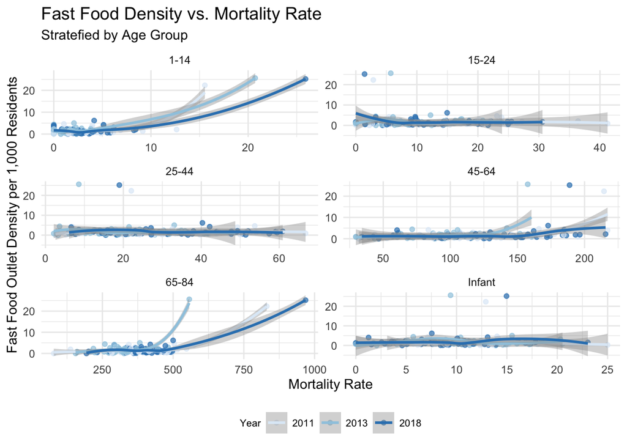

Figure 3: We show the age group trends. Although fast food availability may be linked to poorer health outcomes in theory, these trends are not present in our data. The absence of clear trends and the presence of some extreme outliers prevent us from making any conclusions.

```r
# Relationship between Fast Food Density and Mortality
ggplot(fastfd_mortality_data, aes(x = mort_rate, y = fastfd_rate, color = as.factor(year))) +
  geom_jitter(alpha = 0.7) +
  geom_smooth() +
 facet_wrap(~age_group, scales = "free", ncol = 2) +
  theme_minimal() +
  labs(title = "Fast Food Density vs. Mortality Rate",
       subtitle = "Stratefied by Age Group",
       x = "Mortality Rate",
       y = "Fast Food Outlet Density per 1,000 Residents") +
  scale_color_brewer("Year", palette = "Blues") +
  theme(legend.position = "bottom",
        legend.direction ="horizontal",
        legend.text = element_text(size = 8),
        legend.title = element_text(size = 8),
        plot.title = element_text(size = 14))
```

**Home Internet Access and Mortality Rate Correlation**

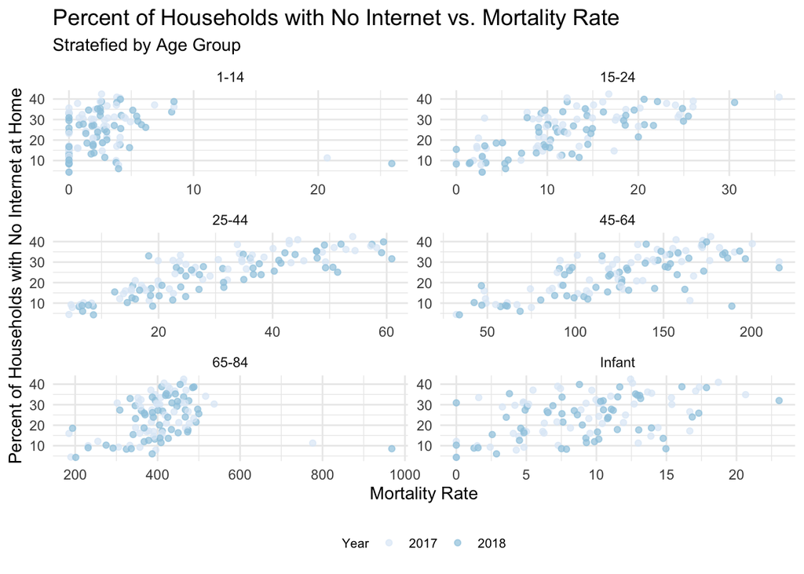

Figure 4: The plot shows a clear positive trend between mortality rate and lack of home internet access, in particular for ages 15-64. The trend is less pronounced in Infant, 1-14, and 65-84 age groups.

```r
ggplot(nohhint_mortality_data, aes(x = mort_rate, y = nohhint_rate, color = as.factor(year))) +
  geom_jitter(alpha = 0.7) +
  facet_wrap(~age_group, scales = "free", ncol = 2) +
  theme_minimal() +
  labs(title = "Percent of Households with No Internet vs. Mortality Rate",
       subtitle = "Stratefied by Age Group",
       x = "Mortality Rate",
       y = "Percent of Households with No Internet at Home") +
  scale_color_brewer("Year", palette = "Blues") +
  theme(legend.position = "bottom",
        legend.direction ="horizontal",
        legend.text = element_text(size = 8),
        legend.title = element_text(size = 8),
        plot.title = element_text(size = 14))
```

**Vehicle Access and Mortality Rate Correlation**

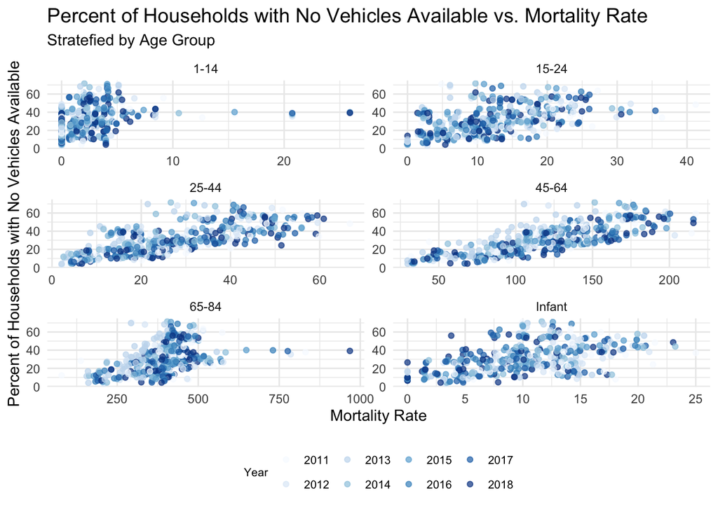

Figure 5: These results suggest that there is indeed a positive correlation between lower rates of vehicle availability and higher rates of mortality Again, the trend is less pronounced in Infant, 1-14, and 65-84 age groups.

```r
ggplot(novhcl_mortality_data, aes(x = mort_rate, y = novhcl_rate, color = as.factor(year))) +
  geom_jitter(alpha = 0.7) +
  facet_wrap(~age_group, scales = "free", ncol = 2) +
  theme_minimal() +
  labs(title = "Percent of Households with No Vehicles Available vs. Mortality Rate",
       subtitle = "Stratefied by Age Group",
       x = "Mortality Rate",
       y = "Percent of Households with No Vehicles Available") +
  scale_color_brewer("Year", palette = "Blues") +
  theme(legend.position = "bottom",
        legend.direction ="horizontal",
        legend.text = element_text(size = 8),
        legend.title = element_text(size = 8),
        plot.title = element_text(size = 14))
```